# Problem Set #3

```r
# if we want to include one interaction term with tensor
# interaction ti()
tiMinGcv <- 100
# summary()
for (i in 3:6) {
    for (j in 3:6) {
        if (i == j) {
            break
        }
        df <- data.frame(c_train_q4_selected[i], c_train_q4_selected[j],
            c_train_q4_selected[1])
        names(df)[1] <- "x1"
        names(df)[2] <- "x2"
        names(df)[3] <- "y"
        tempModel <- gam(Outstate ~ Private + s(S.F.Ratio) +
            s(PhD) + s(perc.alumni) + s(Grad.Rate) + ti(df$x1,
            df$x2), data = c_train_q4_selected, family = gaussian())
        tempGcv <- tempModel$gcv.ubre.dev
        if (tiMinGcv > tempGcv) {
            tiMinGcv <- tempGcv
            tinum1 <- i
            tinum2 <- j
            bestTiModel <- tempModel
        }
    }
}
# plot(bestSModel,pages=1)

print("The gcv for optimal model is")
```

```
## [1] "The gcv for optimal model is"
```

```r
tiMinGcv
```

```
## [1] 0.0505663
```

```r
print("The interaction is between:")
```

```
## [1] "The interaction is between:"
```

```r
names(c_train_q4_selected[tinum1])
```

```
## [1] "perc.alumni"
```

```r
names(c_train_q4_selected[tinum2])
```

```
## [1] "S.F.Ratio"
```

```r
# so we have four optimal models with/without interaction
# in various formula: gcv we got for each model:
gcvSum <- data.frame(fullGamGCV = fullGamGcv, bestTEGCV = temMinGcv,
    bestSGCV = sMinGcv, bestTIGCV = tiMinGcv)
gcvSum
```

| fullGamGCV | bestTEGCV | bestSGCV | bestTIGCV |
| --- | --- | --- | --- |
| 0.05299458 | 0.05067898 | 0.05100146 | 0.0505663 |

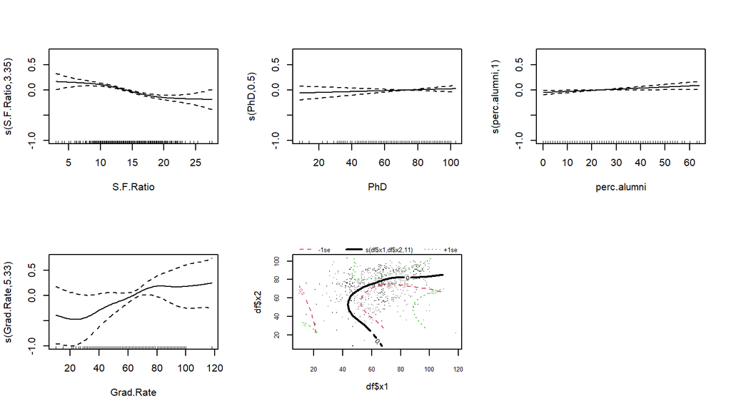

```r
# best Model with one s(interaction) term gam(Outstate ~
# Private+s(S.F.Ratio) + s(PhD) + s(perc.alumni) +
# s(Grad.Rate)+s(Grad.Rate,Phd)
plot(bestSModel, pages = 1)
```

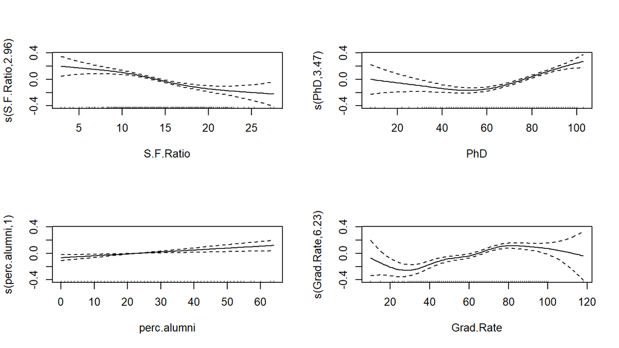

```r
# fullGam model simply s() on everything gam(Outstate ~
# Private+s(S.F.Ratio) + s(PhD) + s(perc.alumni) +
# s(Grad.Rate)
plot(fullGam, pages = 1)
```

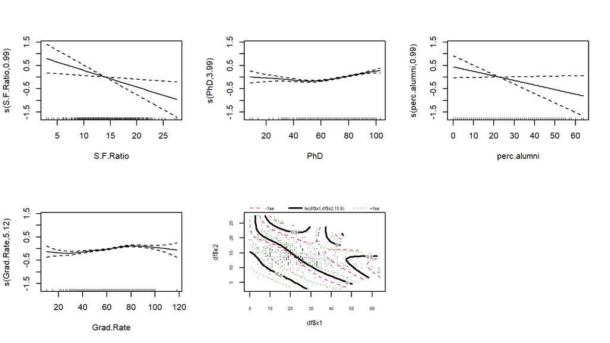

```r
# best Model with one TE(interaction) term gam(Outstate ~
# Private+s(S.F.Ratio) + s(PhD) + s(perc.alumni) +
# s(Grad.Rate)+te(perc.alumni,S.F.Ratio)
plot(bestTEModel, pages = 1)
```

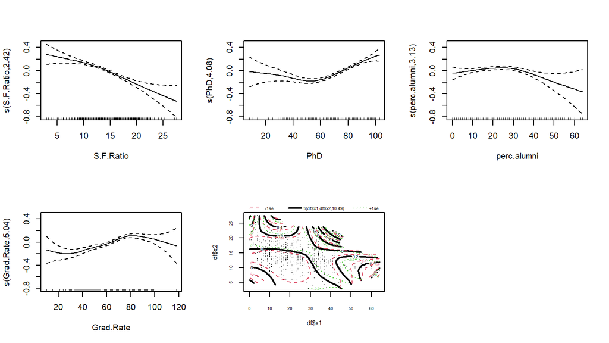

```r
# best Model with one TI(interaction) term gam(Outstate ~
# Private+s(S.F.Ratio) + s(PhD) + s(perc.alumni) +
# s(Grad.Rate)+ti(perc.alumni,S.F.Ratio)
plot(bestTiModel, pages = 1)
```

Create a plot that shows the function for each predictor. Do the marginal relationships make sense? For any 2-predictor spline terms, do they capture anything that wouldn’t be captured by a linear model?

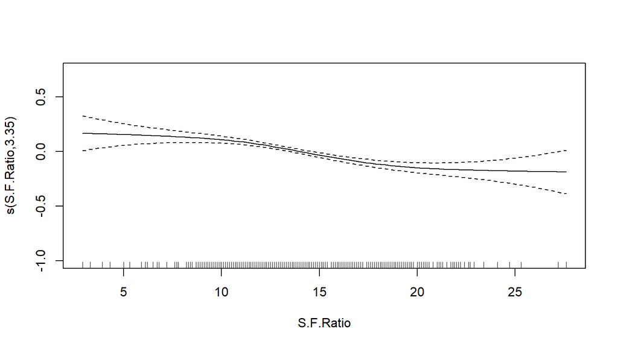

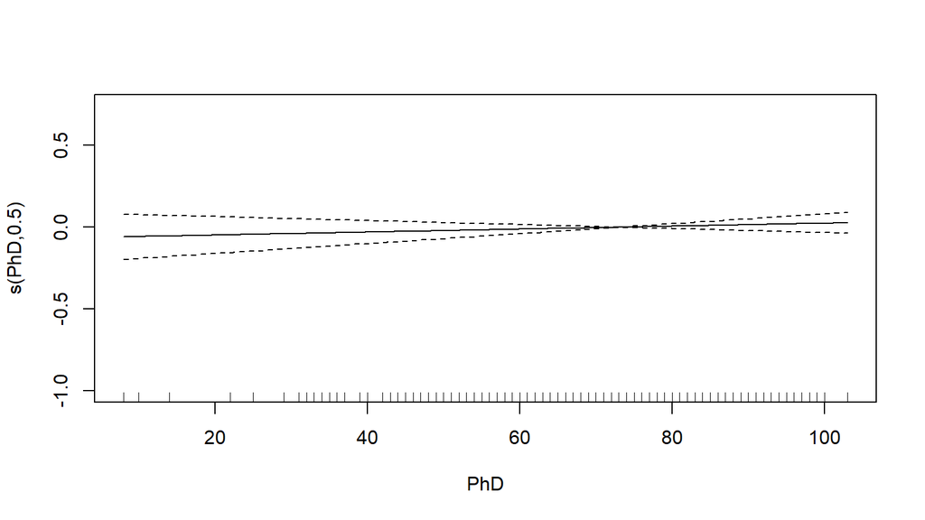

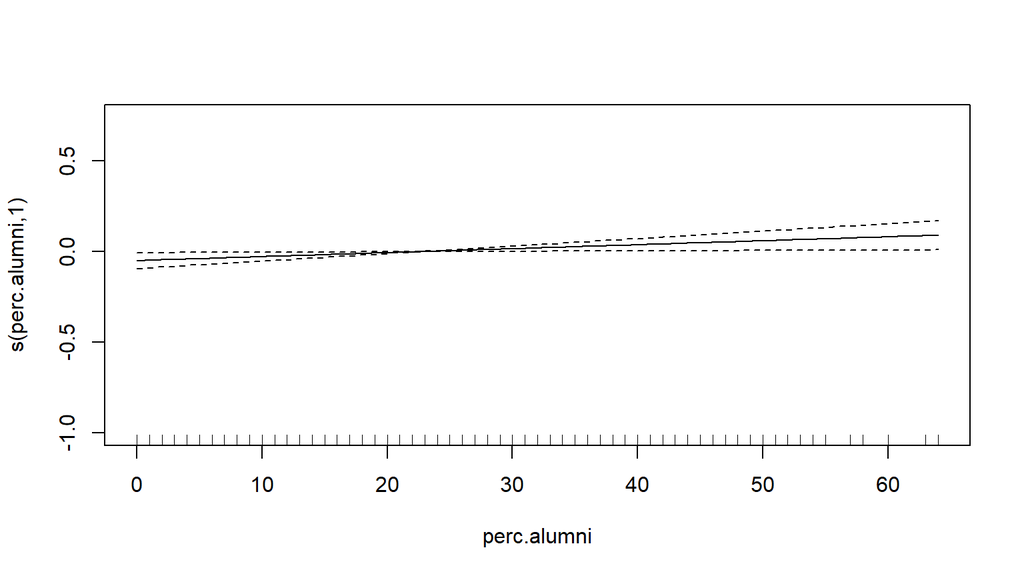

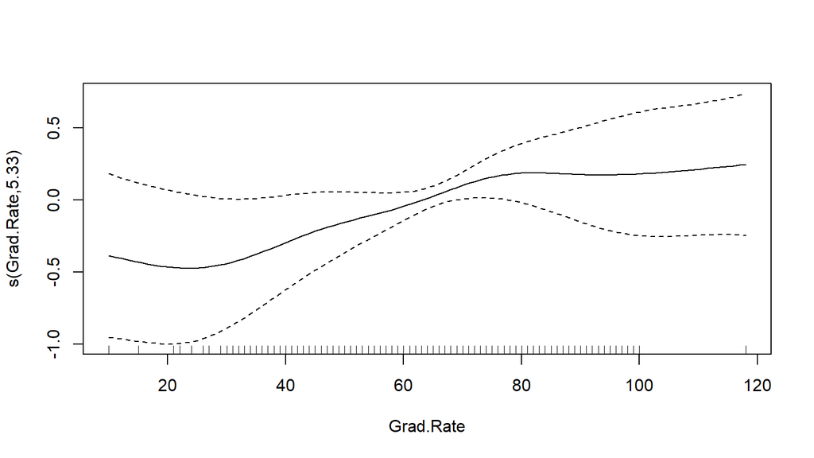

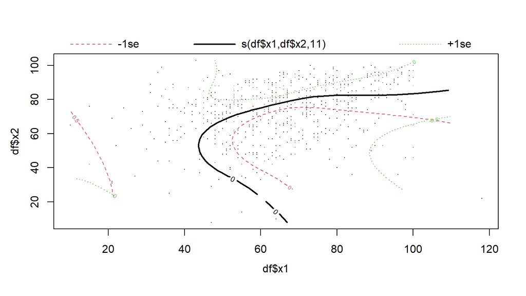

```r
# gam(Outstate ~ Private+s(S.F.Ratio) + s(PhD) +
# s(perc.alumni) + s(Grad.Rate)+s(Grad.Rate,Phd)
optGAMModel <- bestSModel
plot(optGAMModel)
```

```r
# We decide to go with this model as it gives as the
# relatively low gcv with interactions between Grad.Rate
# and Phd (somewhat) makes more sense than other models we
# got. The marginal relationship makes sense most of the
# predictors. For PhD and perc.alumni, it makes sense the
# functions don't change much while the value of those
# variable change.For S.F.Ratio, it also makes sense that
# when the ratio is lower it matters more to out of state
# tuition.(vice versa for Grad.Rate) For 2-predictor spline
# terms, we could see from the last graph that our optimal
# model does capture relation that won't be captured by a
# linear model.
```

Look at your function for `S.F.Ratio`. Does it look like the smoothing spline you uncovered in part 1? What does this say about the plausibility of the additivity assumption for this specific variable?

```r
# s(df$x1, df$x2) is s(Grad.Rate,Phd)
summary(optGAMModel)
```

```
##
## Family: gaussian
## Link function: identity
##
## Formula:
## Outstate ~ Private + s(S.F.Ratio) + s(PhD) + s(perc.alumni) +
##     s(Grad.Rate) + s(df$x1, df$x2)
##
## Parametric coefficients:
##             Estimate Std. Error t value Pr(>|t|)
## (Intercept)  8.92354    0.02208  404.19   <2e-16 ***
## PrivateYes   0.34441    0.02785   12.37   <2e-16 ***
## ---
## Signif. codes:  0 '***' 0.001 '**' 0.01 '*' 0.05 '.' 0.1 ' ' 1
##
## Approximate significance of smooth terms:
##                   edf Ref.df      F p-value
## s(S.F.Ratio)    3.346  4.244 15.335  <2e-16 ***
## s(PhD)          0.500  0.500  1.453  0.3944
## s(perc.alumni)  1.000  1.000  5.072  0.0247 *
## s(Grad.Rate)    5.332  6.285  1.352  0.1975
## s(df$x1,df$x2) 11.000 15.024  5.738  <2e-16 ***
## ---
## Signif. codes:  0 '***' 0.001 '**' 0.01 '*' 0.05 '.' 0.1 ' ' 1
##
## Rank: 65/67
## R-sq.(adj) =  0.697   Deviance explained = 70.8%
## GCV = 0.051001  Scale est. = 0.049031  n = 600
```

```r
# The function we got from the first graph above is quite
# similar with the shape of what we uncovered in part1. It
# might imply that S.F.Ratio is additive to the GAM model
# in the way that we structure it.(as we could see in the
# summary, we have a quite low p-value for S.F.Ratio.)
```

### Part 4 (5 pts)

Finally, let’s compare both models to see which one performs best on the out of sample data. Create predictions using your LASSO model and GAM for the out of sample test data. Use these predictions to compute the out of sample MSE for each method. Which performs best?

```r
# GAM model:optGAMModel
GamPredmodel <- gam(Outstate ~ Private + s(S.F.Ratio) + s(PhD) +
    s(perc.alumni) + s(Grad.Rate) + s(Grad.Rate, PhD), data = c_train_q4_selected,
    family = gaussian())
mse_GAM <- mse(c_test_q4_selected$Outstate, predict.gam(GamPredmodel,
    c_test_q4))

# LASaO model: c_lasso_optimal
lasso_predictor <- data.matrix(c_test_q4[, -9])
mse_Lasoo <- mse(c_test_q4$Outstate, predict(c_lasso_optimal,
    newx = lasso_predictor))

p4p4_mseOutput <- data.frame(GAM_mse = mse_GAM, Lasoo_mse = mse_Lasoo)
p4p4_mseOutput
```

| GAM_mse | Lasoo_mse |
| --- | --- |
| 0.06442234 | 0.04958243 |

```r
# If we take mse data below as reference, Lasso performs
# better than our GAM model.
```

In a few sentences, discuss the practical limitations of the LASSO and GAM approach used in part 3. When will this kind of process not be viable?

The LASSO and GAM approach used in part 3 allows us to pick variable with our own intuition based on some level of logical algorithm analysis. When interactions between variables are significant, we might miss some of those interactions by dropping out some of the variables in the LASSO process. Besides, with GAM, our final *optimal model is highly decided by our human intuition. It does allow us for more freedom on model selection, but also might leads to relatively high bias when we are biased/ don’t have enough knowledge about the data background.